# assignment_health

…

5/13/2022

# Part 1

## Question a

The health department Dataframe named ``Q1.df` has columns related to weight of participants in several months. In this question we are required to select 15 participants for the feb data with replacement technique so we use the `sample` function of R as follows

```r
library(tidyverse)
library(dplyr)
library(caret)
library(rstatix)
```

```r
load(file='AssignmentData (13).RData')


df1 <- Q1.df %>% select(ExerciseFeb,WeightFeb)

df1 <- df1[sample(1:nrow(df1), size=15, replace=T), ]
```

Further we require the 10 participants for calculating the probability that they are exercising for more than 2 days/week so we can use n=10 for probability calculation. We know that out of 15 participants 10 are selected which is approx 66% of total population so we use p=0.66 for our calculation. It can be written as P(X>2)=1−P(X≤2) = 1- pbinom(2,size,prob) where size = 15 for us with n=10. This is done in the code below.

```r
#library(prob)
pbinom(2,15,0.66,lower.tail=FALSE)
```

```
## [1] 0.9999601
```

It means that there is 0.99 probability that the participants have gone for exercise for 2 days/week.

## Question b

For this question we can use the replace=F for subsampling. Note that we have size=10 as given in statement of the question for selection of 10 participants out of month febrary.

```r
df1 <- Q1.df %>% select(ExerciseFeb,WeightFeb)
df1 <- df1[sample(1:nrow(df1), size=10, replace=F), ]
```

For calculating probabilities we can use the pbinom function again where the question is “find the probability that either 2 or 3 participants exercised more than 4 days each week.” It can written as P(2∪3) = P(2) + P(3) – P(2∩3) where 2 and 3 are participants out of 10.

```r
sum(pbinom(2:3,10,0.57))
```

```
## [1] 0.1007459
```

```r
#pbinom(10,15,0.66,lower.tail=FALSE)
```

Here the probability is 0.1 for the participants to go for exercise for more than 4 days in a week.

## Question c

The porportion of population who weigh more than 99kg is calculated by selecting those people who weight is more than 99 kg and it can done by `filter` function.

For this purpose we given 2 hypothesis as - **Null hypothesis H0:** The proportion of people more than 99kg are more than 0.015 of total population going for exercise in feb - **Alternate hypothesis H1:** The proportion of people more than 99kg are less than 0.015 of total population going for exercise in feb. We will test the hypothesis by simple row selection at 2.5% significance level.

```r
df1 <- Q1.df %>% select(ExerciseFeb,WeightFeb) %>%  filter(WeightFeb>99) %>% count()

df1
```

```
##   n
## 1 6
```

It shows that there are only 6 persons who weigh more than 99kg and their percentage in population is given by

```r
nrow(df1)/nrow(Q1.df)
```

```
## [1] 0.003125
```

## Question d

- **Null hypothesis H0**: Proportion of people who exercise 3 or 6 days a week are less in March as compared to feb
- **Alternative hypothesis H1**: Proportion of people who exercise 3 or 6 days a week are more in March as compared to feb

```r
df1 <- Q1.df %>% select(3) %>% filter(ExerciseFeb %in% c("Three","Six"))


df <- Q1.df %>% select(5) %>% filter(ExerciseMar %in% c("Six","Three"))

print(paste("Number of participants ddoing exercise for six or three days in feb are    ",nrow(df1)))
```

```
## [1] "Number of participants ddoing exercise for six or three days in feb are     66"
```

```r
print(paste("Number of participants ddoing exercise for six or three days in March are ",nrow(df)))
```

```
## [1] "Number of participants ddoing exercise for six or three days in March are  83"
```

So the results show that there are more participants in march as compared to feb for our criteria hence we reject our null hypothesis at significance level of 10%.

# Part 2

## Question (a)

It is a choice to select one of two cities so we firstly we select the data of Canberra from year 2002.

```r
df1 <- Q2.df %>% select(3,4) %>% filter(City2002 %in% c("Canberra"))
```

Afterwards we check the normality of the dataset by Shapiro wilk test which is a requirement for all t-tests.

```r
shapiro_test(df1$AvgGrade2002)
```

```
## # A tibble: 1 × 3
##   variable         statistic p.value
##   <chr>                <dbl>   <dbl>
## 1 df1$AvgGrade2002     0.991   0.741
```

We observe that p-value is >0.05 at significance level of 5% as given in question which shows that our data is normal. We proceed towards 1-sample t-test and define our 2 hypothesis as - *Null hypothesis H0*: Population Mean score for Canberra is not greater than 70 - *Alternate hypothesis H1*: Population Mean score for Canberra is greater than 70

We can calculate the mean score, variance and other required variables as below

```r
# mean of sample
mean <- mean(df1$AvgGrade2002)

var <- var(df1$AvgGrade2002)

#theorotical mean of population
mean_of_pop <- mean(Q2.df$AvgGrade2002)

# standard deviation of sample
stand <-  sd(df1$AvgGrade2002)
# sample size
row <-  nrow(df1)

t_1_sample_test <- (mean - mean_of_pop)/stand/sqrt(row)
t_1_sample_test
```

```
## [1] -0.02460958
```

## Question (b)

We have been given population variance here of 64 for all cities. We have to test the population mean average of student scores from 2 cities so we define our hypotheses as;

- *H0:* Population mean average grade of Sydney students is higher than students from Canbera by 0.1
- *H1:* Population mean average grade of Sydney students is not higher than students from Canbera by 0.1

Here we need to compare population means for two groups so we can use independent sample t-test at significance level (alpha) of 5%.

Before the t-test we need to use the shapiro wilk test to check normality of data. We will do it for both cities according to requirement of the question.

```r
df1 <- Q2.df %>% filter(City2002=="Sydney") %>% select(AvgGrade2002)


shapiro_test(df1$AvgGrade2002)
```

```
## # A tibble: 1 × 3
##   variable         statistic   p.value
##   <chr>                <dbl>     <dbl>
## 1 df1$AvgGrade2002     0.931 0.0000638
```

```r
df2<- Q2.df %>% filter(City2002=="Canberra") %>% select(AvgGrade2002)

shapiro_test(df2$AvgGrade2002)
```

```
## # A tibble: 1 × 3
##   variable         statistic p.value
##   <chr>                <dbl>   <dbl>
## 1 df2$AvgGrade2002     0.991   0.741
```

The p-value is <0.05 for Sydney data as compared to Canberra where p-value is >0.05 so both the sample datasets are different from each other, hence we cannot compare the means of the two datasets according to independent t-test which is based on the assumption that the two independent samples are normally distributed.

In this scenario, we can move towards Wilcoxon Rank sum test which doesn’t require the normality of data in 2 independent groups with same variance.

## Question (c)

This question requires the testing for population variance ($/sigma^2$) for two cities Melbourne and Perth. The variance is given by formula

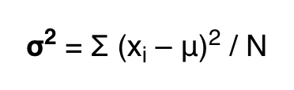

For the analysis we firstly get the subset of data from main dataset.

```r
df1 <-  Q2.df %>% filter(City2002 == "Melbourne")
df2 <-  Q2.df %>% filter(City2002 == "Perth")
```

We need to check the normality of our datasets before hand

```r
shapiro_test(df1$AvgGrade2002)
```

```
## # A tibble: 1 × 3
##   variable         statistic p.value
##   <chr>                <dbl>   <dbl>
## 1 df1$AvgGrade2002     0.981   0.167
```

```r
shapiro_test(df2$AvgGrade2002)
```

```
## # A tibble: 1 × 3
##   variable         statistic p.value
##   <chr>                <dbl>   <dbl>
## 1 df2$AvgGrade2002     0.991   0.757
```

In both cases the p-value is greater than alpha = 0.01 which is our chosen significance level, therefore we move towards F-test for comparison of variances. The hypothesis for the tests are; - *null hpothesis H0* The variance of avg grades of students of Melbourne and perth is equal - *Alternate hypothesis H1* The variance of avg grades of students of Melbourne and perth is not equal

It includes calculation of variances individually and dividing them.

```r
var1 <- var(df1$AvgGrade2002)
var2 <- var(df2$AvgGrade2002)

F_test <-  var1/var2
F_test
```

```
## [1] 0.8623273
```

## Question (d)

In this question we are again using the dataset from previous question so the hypothesis with a little change can be written as

- *H0:* mean avg grade for perth students is equal to Melbourne students
- *H1:* mean avg grade for perth students is not equal to Melbourne students

This can be tested with the help of welch t-stats since their variance is different at alpha=10% as follows

```r
# mean of 2 groups from perth and melbourne
mean1 <-  mean(df1$AvgGrade2002)
mean2 <- mean(df2$AvgGrade2002)

#standard deviation of 2 groups
var1 <- sd(df1$AvgGrade2002)
var2 <-  sd(df2$AvgGrade2002)

t <- mean1 - mean2/sqrt((var1^2/nrow(df1))+(var2^2/nrow(df2)))
t
```

```
## [1] 5.915881
```

## Question (e)

{Test whether the population mean average grade for students is the same for all five cities. Clearly state your hypotheses and use a significance level of α = 5%. Do not use any R functions that are designed to perform hypothesis tests or to perform, analyse or interpret an ANOVA. } In this question we can compare all five cities with the help of ANOVA test since it involves more than 2 groups. We can write our hypothesis as

- *H0:* There is no significant difference between means of avg score of all 5 cities
- *H1:* There is significant difference between means of avg score of all 5 cities

It is important to check the normality of dataset before conducting parametric tests. The significance level is 5% here.

```r
df1 <-  Q2.df %>% select(2,4,6,8,10)

shapiro_test(df1$AvgGrade2001,df1$AvgGrade2002,df1$AvgGrade2003,df1$AvgGrade2004,df1$AvgGrade2005)
```

```
## # A tibble: 1 × 3
##   variable         statistic p.value
##   <chr>                <dbl>   <dbl>
## 1 df1$AvgGrade2001     0.995   0.107
```

The one-way ANOVA test can be done as following

SSB = Σ(Xi – Xt)² where Xi is mean of group i and Xt is mean of all the observations.

```r
mea <- mean(sum(colMeans(df1)))
SSB <-  sum((mean(df1$AvgGrade2001)-mea)^2+
              (mean(df1$AvgGrade2002)-mea)^2+
              (mean(df1$AvgGrade2003)-mea)^2+
              (mean(df1$AvgGrade2004)-mea)^2+
              (mean(df1$AvgGrade2005)-mea)^2)


# dgress of freedom since we have 5 groups so
dfb  <-  5-1

# DFw = degrees of freedom = N – K where K is the number of group, and N is total number of observations in all the group

DFw <- nrow(df1) - 5

# SSW = Σ(Xij – Xj)² where Xij is the observation of each group j

SSW <-  sum(
  sum(df1$AvgGrade2001-mean(df1$AvgGrade2001))^2+
     sum(df1$AvgGrade2002-mean(df1$AvgGrade2002))^2+
           sum(df1$AvgGrade2003-mean(df1$AvgGrade2003))^2+
                 sum(df1$AvgGrade2004-mean(df1$AvgGrade2004))^2+
                       sum(df1$AvgGrade2005-mean(df1$AvgGrade2005))^2)

SST <-  sum(
 (df1$AvgGrade2001-mea)^2+(df1$AvgGrade2002-mea)^2+(df1$AvgGrade2003-mea)^2+(df1$AvgGrade2004-mea)^2+(df1$AvgGrade2005-mea)^2
)

MSB <-  SSB/dfb
MSE <-  SSW/DFw

f_stat <- MSB/MSE
f_stat
```

```
## [1] 2.469408e+30
```

The F-statistics value is very large which means that there is significant difference between means of all cities avg score.

##Question (f)

# Part 3

## Question (a)

For the analysis we select the data from Cholestrol50 and 52 as given.

```r
df1 <- Q3.df %>% select(Cholesterol50,Cholesterol52)
```

Scatter plot for 2 variables is given below

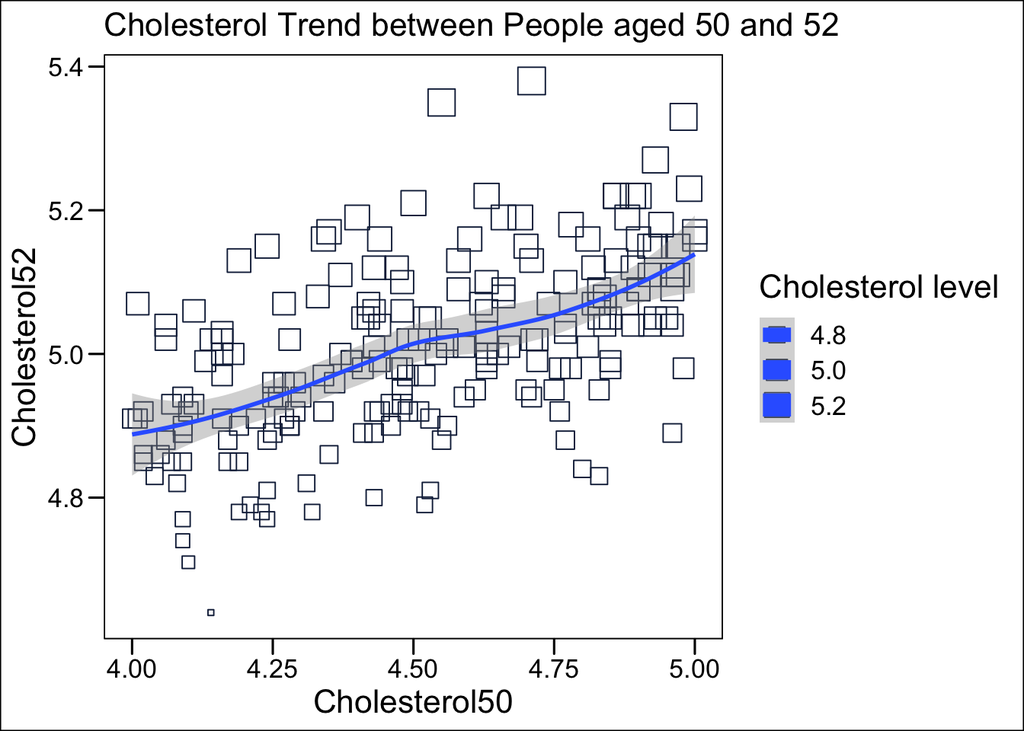

```r
ggplot(df1) +
 aes(x = Cholesterol50, y = Cholesterol52, size = Cholesterol52) +
 geom_point(shape = "square open",
 colour = "#112446") +
 geom_smooth(span = 0.75) +
 labs(subtitle = "Cholesterol Trend between People aged 50 and 52",
 size = "Cholesterol level") +
 ggthemes::theme_base()
```

We observe that cholesterol levels in the people aged 50 and 52 have almost linear relationship with each other. There are some cases with level of cholesterol in both categories as shown by size legend in the figure above. Although the cases with level from less than 4.8 are present in both age groups yet the cholestrol levels in age group 52 is higher as compared to group 50.

## Question (b)

At Significance level of 5% we can test the following hypothesis.

- *H0:* There exists significant difference between mean values of cholestrol for age group 50 and 52
- *H1:* There is no significant difference between mean values of cholestrol for age group 50 and 52

It can tested by 2 sample t-test but it needs to be checked by normality test.

```r
shapiro_test(df1$Cholesterol50)
```

```
## # A tibble: 1 × 3
##   variable          statistic    p.value
##   <chr>                 <dbl>      <dbl>
## 1 df1$Cholesterol50     0.953 0.00000352
```

```r
shapiro_test(df1$Cholesterol52)
```

```
## # A tibble: 1 × 3
##   variable          statistic p.value
##   <chr>                 <dbl>   <dbl>
## 1 df1$Cholesterol52     0.996   0.922
```

The result show that p-value for 2 groups are different so at significance level of 0.005 the 50 age group dataset is not normal while the other one is normally distributed.

In this scenario we can use paired t-test with the assumptions that our sample size is more than 30 so results are not going be too much affected by the normality of the sample.

We can further analyse this for the 50 age group by checking outliers with the help of boxplot.

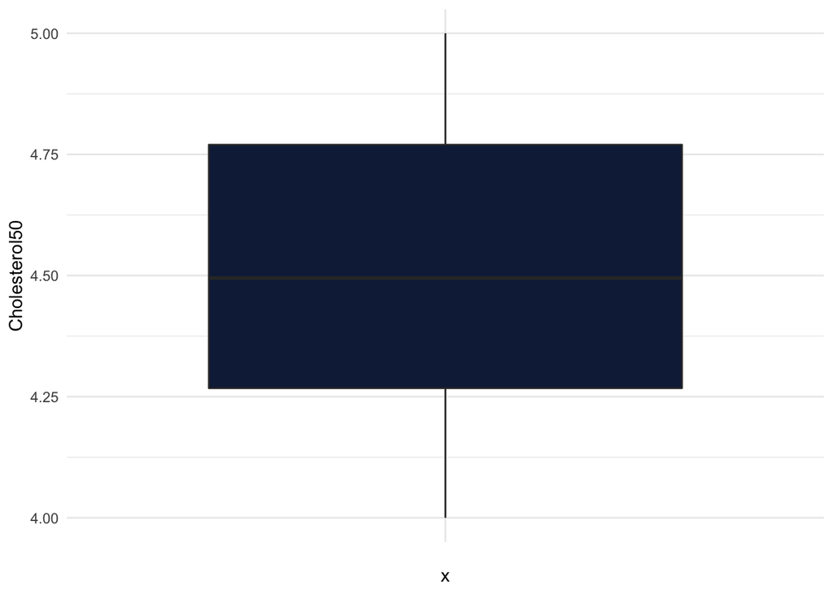

```r
library(ggplot2)

ggplot(df1) +
 aes(x = "", y = Cholesterol50) +
 geom_boxplot(fill = "#112446") +
 theme_minimal()
```

There are no outliers even if the p-value is less than alpha so we proceed with paired t-test.

```r
sample_mean_of_diff <- mean(df1$Cholesterol52-df1$Cholesterol50)

stand <-  sd(df1$Cholesterol52-df1$Cholesterol50)

t <-  sample_mean_of_diff/(stand/sqrt(nrow(df1)))

t
```

```
## [1] 28.638
```

```r
mean(df1$Cholesterol52)
```

```
## [1] 5.005
```

##Question (c)

```r
model <- lm(df1$Cholesterol52 ~ df1$Cholesterol50, data = df1)

summary(model)
```

```
##
## Call:
## lm(formula = df1$Cholesterol52 ~ df1$Cholesterol50, data = df1)
##
## Residuals:
##      Min       1Q   Median       3Q      Max
## -0.27515 -0.06136 -0.00621  0.06361  0.33576
##
## Coefficients:
##                   Estimate Std. Error t value Pr(>|t|)
## (Intercept)        3.91452    0.11417  34.286   <2e-16 ***
## df1$Cholesterol50  0.24170    0.02525   9.571   <2e-16 ***
## ---
## Signif. codes:  0 '***' 0.001 '**' 0.01 '*' 0.05 '.' 0.1 ' ' 1
##
## Residual standard error: 0.1036 on 198 degrees of freedom
## Multiple R-squared:  0.3163, Adjusted R-squared:  0.3128
## F-statistic:  91.6 on 1 and 198 DF,  p-value: < 2.2e-16
```

The estimated regression model is
$$Cholestrol52 =
0.2417*Cholestrol50+3.914$$

##Question (d)

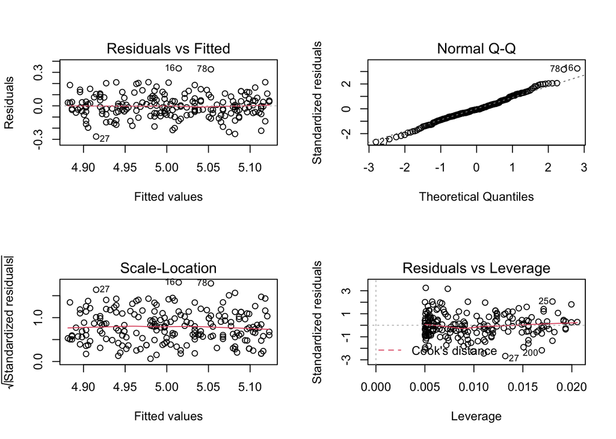

```r
par(mfrow=c(2,2))
plot(model)
```

```r
par(mfrow=c(1,1))
```

QQ-plot has a strainght line which confirms our basic assumption of using paired t-test in question (b).

## Question (f)

To check confidence interval of 90% we use with the assumptions

CI = Mean value $\pm$ (t-statistic or z-statistic)*std

where t-statistics is 2.175 for given confidence interval of 90%. The value provided is 3.7 so we use the values in formula and calculate it as

```r
# CI = mean(df1$Cholesterol50) + (2)*sd(df1$Cholesterol50)
#
# CI
#
# # we can also use

CI <- mean(df1$Cholesterol50) + 2.175*sqrt(3.7/500)
CI
```

```
## [1] 4.698851
```

With regards to accuracy the trend is tend to rise which is good enough according the old model.